| title: “Analysis of BABE data” |
| --- |
| author: “Diksha Patil” |
| date: “05/11/2022” |
| output: html_document |

# Introduction

To study effect estimation with the help of PK Parameters here we are using BABEData and BABEData22. we have data for two by two cross over design. I have stored this data in clinical trials folder in C drive in CSV format .In these data there are 24 subjects and also Period ,Sequence ,Treatment and Concentration data with time points are also given for all subjects.For total subjects we are calculating PK parameters,Carryover Effect.

- Here data extraction is done. Concentration data and time point are seperated to code further easily.

```r
df1=read.csv("C:\\Users\\FLUTE\\Desktop\\Diksha\\Statistics\\Third Sem\\ST 306\\MCP\\Clinical Trials\\BABEData.csv",header = F)
data=read.csv("C:\\Users\\FLUTE\\Desktop\\Diksha\\Statistics\\Third Sem\\ST 306\\MCP\\Clinical Trials\\BABEData.csv")
time_c=df1[1,5:20]
conc=df1[2:49,5:20]
```

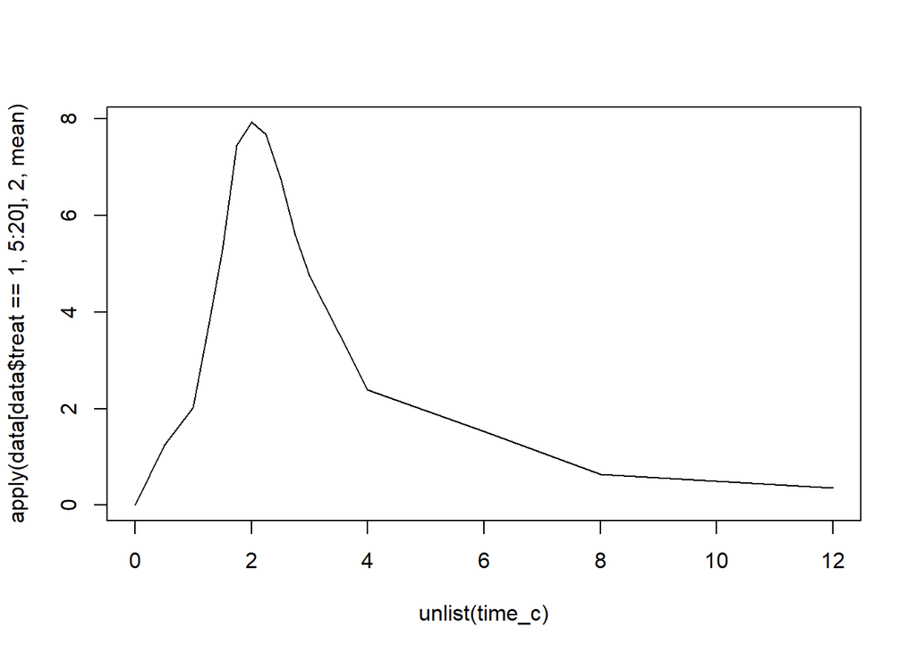

```r
plot(unlist(time_c),apply(data[data$treat==1,5:20],2,mean),type="l")
```

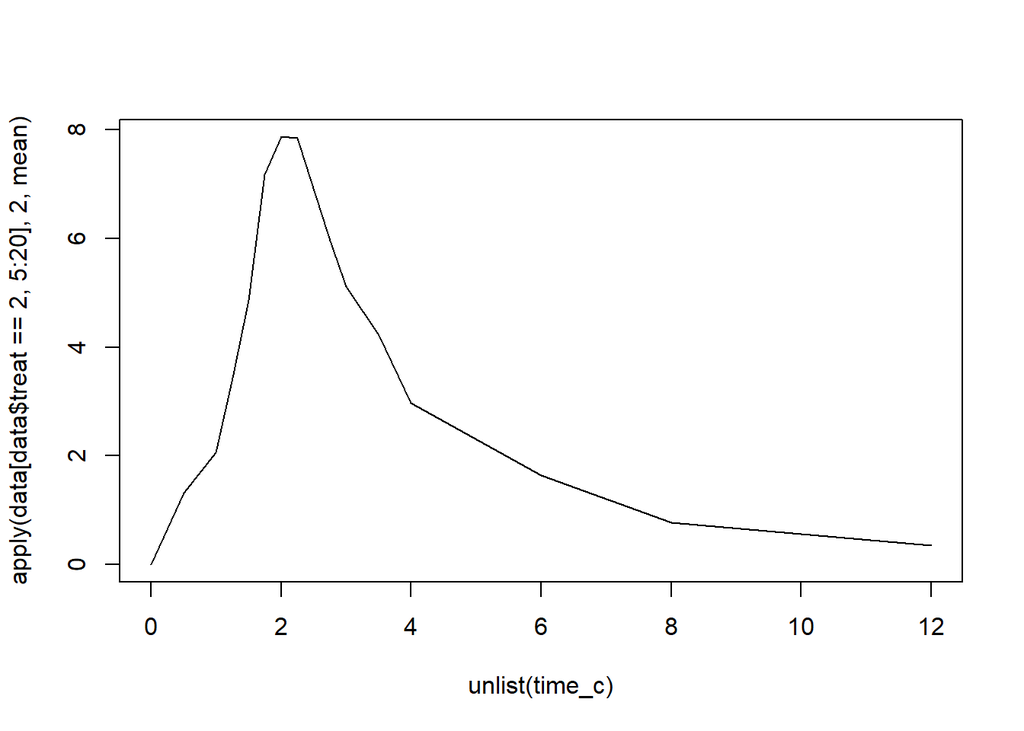

```r
plot(unlist(time_c),apply(data[data$treat==2,5:20],2,mean),type="l")
```

* Create function for pk parameters

```r
pkpara=function(time_temp,conc_temp)
  {
  n=length(conc_temp)
  pkpara=data.frame("Tmax"=0,"Cmax"=0,"AUCt"=0,"AUCinf"=0,"Thalf"=0,"Ke"=0)
  pkpara$Cmax=max(conc_temp)
  a=which.max(conc_temp)
  pkpara$Tmax=time_temp[a]
  pkpara$AUCt=sum((conc_temp[2:n]+conc_temp[1:(n-1)])*
                    (time_temp[2:n]-time_temp[1:(n-1)]))/2
  pkpara$Ke=-2.303*coefficients(lm(log10(conc_temp[(a+1):n])~time_temp[(a+1):n]))[2]
  pkpara$Thalf=0.693/pkpara$Ke
  pkpara$AUCinf=pkpara$AUCt+conc_temp[n]/pkpara$Ke
 return(pkpara)
  }
```

```r
out=data.frame("Tmax"=rep(0,48),"Cmax"=rep(0,48),"AUCt"=rep(0,48),"AUCinf"=rep(0,48),"Thalf"=rep(0,48),"Ke"=rep(0,48))
for(i in 1:48){
  out[i,]=pkpara(as.numeric(unlist(time_c)),as.numeric(unlist(conc[i,])))
}
summary(out)
```

```
##       Tmax            Cmax             AUCt           AUCinf
##  Min.   :1.500   Min.   : 5.987   Min.   :17.20   Min.   :17.91
##  1st Qu.:1.750   1st Qu.: 7.569   1st Qu.:22.05   1st Qu.:23.28
##  Median :2.000   Median : 8.150   Median :25.03   Median :26.05
##  Mean   :1.964   Mean   : 8.533   Mean   :25.60   Mean   :26.70
##  3rd Qu.:2.250   3rd Qu.: 9.628   3rd Qu.:28.62   3rd Qu.:29.88
##  Max.   :2.250   Max.   :11.547   Max.   :34.44   Max.   :35.82
##      Thalf             Ke
##  Min.   :1.620   Min.   :0.2797
##  1st Qu.:2.037   1st Qu.:0.3022
##  Median :2.152   Median :0.3221
##  Mean   :2.142   Mean   :0.3262
##  3rd Qu.:2.293   3rd Qu.:0.3402
##  Max.   :2.477   Max.   :0.4278
```

```r
seq1=sapply(out[data$seq==1,],summary);seq1
```

```
##             Tmax      Cmax     AUCt   AUCinf    Thalf        Ke
## Min.    1.500000  5.987000 17.19537 17.90923 1.907471 0.2797196
## 1st Qu. 1.750000  7.956000 22.04697 23.45399 2.000576 0.3051627
## Median  2.000000  8.236500 26.37156 27.70562 2.129673 0.3254132
## Mean    2.010417  8.899458 26.28526 27.39005 2.129314 0.3270709
## 3rd Qu. 2.250000 10.438500 29.89759 31.33144 2.270926 0.3464017
## Max.    2.250000 11.547000 34.43512 35.82114 2.477481 0.3633083
```

```r
seq2=sapply(out[data$seq==2,],summary);seq2
```

```
##             Tmax      Cmax     AUCt   AUCinf    Thalf        Ke
## Min.    1.500000  6.032000 19.13125 20.11394 1.620048 0.2811932
## 1st Qu. 1.750000  7.481500 22.19947 23.28332 2.079900 0.2993770
## Median  1.750000  7.910500 24.63675 25.68666 2.195091 0.3157145
## Mean    1.916667  8.167125 24.91121 26.01634 2.154651 0.3252599
## 3rd Qu. 2.062500  8.948500 27.17162 28.22533 2.314807 0.3331908
## Max.    2.250000 10.820000 33.78200 34.11396 2.464498 0.4277651
```

```r
Treat1=sapply(out[data$treat==1,],summary);Treat1
```

```
##             Tmax      Cmax     AUCt   AUCinf    Thalf        Ke
## Min.    1.500000  5.987000 17.19537 17.90923 1.778940 0.2811932
## 1st Qu. 1.750000  7.728500 20.33881 21.75831 2.030626 0.3090528
## Median  2.000000  8.150500 24.00806 25.45265 2.144161 0.3232034
## Mean    1.927083  8.537542 24.69217 25.80924 2.142156 0.3252453
## 3rd Qu. 2.062500  9.237750 27.91944 29.07368 2.242438 0.3412901
## Max.    2.250000 11.547000 34.37562 35.82114 2.464498 0.3895578
```

```r
Treat2=sapply(out[data$treat==2,],summary);Treat2
```

```
##         Tmax      Cmax     AUCt   AUCinf    Thalf        Ke
## Min.    1.75  6.032000 19.13125 20.11394 1.620048 0.2797196
## 1st Qu. 1.75  7.323500 23.16547 24.21408 2.039212 0.2993770
## Median  2.00  8.179000 26.40550 27.72891 2.194226 0.3158376
## Mean    2.00  8.529042 26.50430 27.59715 2.141809 0.3270854
## 3rd Qu. 2.25  9.982750 29.23131 30.53457 2.314807 0.3398384
## Max.    2.25 10.868000 34.43512 35.35856 2.477481 0.4277651
```

```r
Per1=sapply(out[data$Per==1,],summary);Per1
```

```
##            Tmax     Cmax     AUCt   AUCinf    Thalf        Ke
## Min.    1.50000  5.98700 17.19537 17.90923 1.620048 0.2968840
## 1st Qu. 1.75000  6.90875 20.12234 20.48773 2.054625 0.3022207
## Median  2.00000  7.82800 23.92444 25.41533 2.167440 0.3197471
## Mean    1.96875  8.24025 25.08734 26.12463 2.131652 0.3282041
## 3rd Qu. 2.25000  9.46925 30.54184 31.82271 2.293029 0.3373601
## Max.    2.25000 11.54700 34.37562 35.82114 2.334245 0.4277651
```

```r
Per2=sapply(out[data$Per==2,],summary);Per2
```

```
##             Tmax      Cmax     AUCt   AUCinf    Thalf        Ke
## Min.    1.500000  6.925000 19.17550 20.72421 1.778940 0.2797196
## 1st Qu. 1.750000  7.997250 23.38750 24.80034 2.037168 0.3028115
## Median  2.000000  8.600000 26.10656 27.42754 2.142465 0.3234592
## Mean    1.958333  8.826333 26.10912 27.28176 2.152313 0.3241266
## 3rd Qu. 2.250000  9.661750 28.19966 29.29395 2.288721 0.3401787
## Max.    2.250000 10.868000 34.43512 35.35856 2.477481 0.3895578
```

- Combine the data

```r
df3=df1[2:49,1:4]
colnames(df3)=df1[1,1:4]
df3=cbind(df3,out)
```

```r
eff=function(df,alpha){
Y11=df[df$Per==1&df$Seq==1,1]; n1=length(Y11)
Y12=df[df$Per==1&df$Seq==2,1]
Y21=df[df$Per==2&df$Seq==1,1];n2=length(Y21)
Y22=df[df$Per==2&df$Seq==2,1]

U1=Y11+Y21; U2=Y12+Y22;
D1=(Y21-Y11)/2; D2=(Y22-Y12)/2;
O1=D1;O2=-D2
sig2u=((n1-1)*var(U1)+(n2-1)*var(U2))/(n1+n2-2)
sig2d=((n1-1)*var(D1)+(n2-1)*var(D2))/(n1+n2-2)


#Carryover Effect

Chat=mean(U2)-mean(U1);   VChat=sig2u*(1/n1+1/n2);
Fhat=mean(D1)-mean(D2);   VFhat=sig2d*(1/n1+1/n2);
Phat=mean(O1)-mean(O2);

Effect=c("Carry","Drug","Period")
MVUE=c(Chat,Fhat,Phat)
Vhat=c(VChat,VFhat,VFhat)
tst=MVUE/sqrt(Vhat)
pv=2*(1-pt(abs(tst),n1+n2-2))
lowerCI=MVUE-qt(1-alpha/2,n1+n2-2)*sqrt(Vhat)
upperCI=MVUE+qt(1-alpha/2,n1+n2-2)*sqrt(Vhat)
df2=data.frame(Effect,MVUE,Vhat,tst,pv,lowerCI,upperCI)
return(df2)
}
```

- Effect Estimation for Cmax

```r
alpha=0.05
df_temp=data.frame("Y"=df3$Cmax,"Per"=df3$Per,"Sub"=df3$Sub,"Seq"=df3$seq)
eff(df_temp,alpha)
```

```
##   Effect       MVUE      Vhat         tst         pv    lowerCI   upperCI
## 1  Carry -1.4646667 0.6103738 -1.87473926 0.07416735 -3.0849095 0.1555761
## 2   Drug -0.0085000 0.2042861 -0.01880614 0.98516528 -0.9458495 0.9288495
## 3 Period  0.5860833 0.2042861  1.29670147 0.20817029 -0.3512661 1.5234328
```

- Effect Estimation for Tmax

```r
alpha=0.05
df_temp=data.frame("Y"=df3$Tmax,"Per"=df3$Per,"Sub"=df3$Sub,"Seq"=df3$seq)
eff(df_temp,alpha)
```

```
##   Effect        MVUE        Vhat        tst        pv     lowerCI   upperCI
## 1  Carry -0.18750000 0.019689078 -1.3362526 0.1951245 -0.47850126 0.1035013
## 2   Drug  0.07291667 0.003896386  1.1681425 0.2552530 -0.05653664 0.2023700
## 3 Period -0.01041667 0.003896386 -0.1668775 0.8689908 -0.13986997 0.1190366
```

```r
alpha=0.05
df_temp=data.frame("Y"=df3$AUCt,"Per"=df3$Per,"Sub"=df3$Sub,"Seq"=df3$seq)
eff(df_temp,alpha)
```

```
##   Effect      MVUE     Vhat        tst        pv   lowerCI  upperCI
## 1  Carry -2.748083 6.340957 -1.0913209 0.2869400 -7.970357 2.474190
## 2   Drug  1.812125 2.191948  1.2239764 0.2339081 -1.258291 4.882541
## 3 Period  1.021781 2.191948  0.6901489 0.4973173 -2.048635 4.092198
```

- Effect Estimation for AUCinf

```r
alpha=0.05
df_temp=data.frame("Y"=df3$AUCinf,"Per"=df3$Per,"Sub"=df3$Sub,"Seq"=df3$seq)
eff(df_temp,alpha)
```

```
##   Effect      MVUE     Vhat        tst        pv   lowerCI  upperCI
## 1  Carry -2.747427 6.693376 -1.0619489 0.2997779 -8.112860 2.618006
## 2   Drug  1.787902 2.287711  1.1820701 0.2497974 -1.348868 4.924673
## 3 Period  1.157126 2.287711  0.7650326 0.4523813 -1.979645 4.293896
```

- Effect Estimation for Thalf

```r
alpha=0.05
df_temp=data.frame("Y"=df3$Thalf,"Per"=df3$Per,"Sub"=df3$Sub,"Seq"=df3$seq)
eff(df_temp,alpha)
```

```
##   Effect          MVUE        Vhat          tst        pv    lowerCI   upperCI
## 1  Carry  0.0506746229 0.009133088  0.530251240 0.6012494 -0.1475196 0.2488689
## 2   Drug -0.0003469899 0.003861341 -0.005584031 0.9955949 -0.1292168 0.1285228
## 3 Period  0.0206612751 0.003861341  0.332497221 0.7426612 -0.1082086 0.1495311
```

- Effect Estimation for Ke

```r
alpha=0.05
df_temp=data.frame("Y"=df3$Ke,"Per"=df3$Per,"Sub"=df3$Sub,"Seq"=df3$seq)
eff(df_temp,alpha)
```

```
##   Effect         MVUE         Vhat        tst        pv     lowerCI    upperCI
## 1  Carry -0.003622104 0.0002605304 -0.2244046 0.8245135 -0.03709639 0.02985219
## 2   Drug  0.001840065 0.0001068345  0.1780235 0.8603336 -0.01959565 0.02327578
## 3 Period -0.004077528 0.0001068345 -0.3944947 0.6970141 -0.02551324 0.01735819
```

## ANOVA

Now we create a general function to find the ANOVA for all Pkparameter.

```r
df=read.csv("C:\\Users\\FLUTE\\Desktop\\Diksha\\Statistics\\Third Sem\\ST 306\\MCP\\Clinical Trials\\BABEData22.csv")
Diksha=function(Y,Seq,Per,Sub)
{
n=length(df$Y)
SST=(n-1)*var(df$Y)
df=data.frame(Y,Seq,Per,Sub)
Y11=df[df$Per==1&df$Seq==1,1];n1=length(Y11)
Y12=df[df$Per==1&df$Seq==2,1]
Y21=df[df$Per==2&df$Seq==1,1]
Y22=df[df$Per==2&df$Seq==2,1];n2=length(Y22)
df_temp=data.frame(t1=c(Y11,Y12),t2=c(Y21,Y22))
SSWithin=sum(apply(df_temp,1,var))
SSBetween=2*sum((apply(df_temp,1,mean)-mean(df$Y))^2) #By using formula

# Now we slite SSbetween.
#SSBetween=SScarry + SSinter
U1=Y11+Y21; U2=Y12+Y22;
Chat=(mean(Y12)+mean(Y22))-(mean(Y11)+mean(Y21));
SScarry=2*n1*n2/(n1+n2)*Chat^2/4
SSinter=SSBetween-SScarry

Fhat=(((mean(Y21)-mean(Y11))-(mean(Y22)-mean(Y12)))/2)
SSdrug=2*n1*n2/(n1+n2)*Fhat^2

Phat=(((mean(Y21)-mean(Y11))-(mean(Y12)-mean(Y22)))/2)
SSperiod=2*n1*n2/(n1+n2)*Phat^2

SSintra=SSWithin-SSdrug-SSperiod
source1=c("carry","inter","drug","period","intra","Total")
SS=c(SScarry,SSinter,SSdrug,SSperiod,SSintra,SST)
df=c(1,n1+n2-2,1,1,n1+n2-2,2*(n1+n2)-1)
Msq=SS/df
Fcal=rep(0,6)
Fcal[1]=Msq[1]/Msq[2]
Fcal[2:4]=Msq[2:4]/Msq[5]
Pval=rep(0,6)
Pval[1]=1-pf(Fcal[1],df[1],df[2])
Pval[2:4]=1-pf(Fcal[2:4],df[2:4],df[5])
return(data.frame("Source"=source1,"Df"=df,"Summofsq"=SS,"Msq"=Msq,"Fcal"=Fcal,"Pvalue"=Pval))
}
Diksha("Y"=df$Y,"Seq"=df$Seq,"Per"=df$Per,"Sub"=df$Sub)
```

```
##   Source Df    Summofsq       Msq      Fcal       Pvalue
## 1  carry  1   276.00021 276.00021 0.3745495 0.5468084159
## 2  inter 22 16211.48870 736.88585 4.4059789 0.0004841387
## 3   drug  1    62.79188  62.79188 0.3754444 0.5463338016
## 4 period  1    35.96672  35.96672 0.2150518 0.6473919310
## 5  intra 22  3679.42953 167.24680 0.0000000 0.0000000000
## 6  Total 47 20265.67703 431.18462 0.0000000 0.0000000000
```

- ANOVA for Tmax

```r
Diksha("Y"=df3$Tmax,"Seq"=df3$seq,"Per"=df3$Per,"Sub"=df3$Sub)
```

```
##   Source Df     Summofsq          Msq      Fcal    Pvalue
## 1  carry  1 1.054688e-01 1.054688e-01 1.7855711 0.1951245
## 2  inter 22 1.299479e+00 5.906723e-02 1.2632911 0.2941422
## 3   drug  1 6.380208e-02 6.380208e-02 1.3645570 0.2552530
## 4 period  1 1.302083e-03 1.302083e-03 0.0278481 0.8689908
## 5  intra 22 1.028646e+00 4.675663e-02 0.0000000 0.0000000
## 6  Total 47 2.026568e+04 4.311846e+02 0.0000000 0.0000000
```

- ANOVA for Cmax

```r
Diksha("Y"=df3$Cmax,"Seq"=df3$seq,"Per"=df3$Per,"Sub"=df3$Sub)
```

```
##   Source Df     Summofsq        Msq         Fcal     Pvalue
## 1  carry  1     6.435745   6.435745 3.5146472796 0.07416735
## 2  inter 22    40.284668   1.831121 0.7469596193 0.75025498
## 3   drug  1     0.000867   0.000867 0.0003536707 0.98516528
## 4 period  1     4.121924   4.121924 1.6814347152 0.20817029
## 5  intra 22    53.931520   2.451433 0.0000000000 0.00000000
## 6  Total 47 20265.677031 431.184618 0.0000000000 0.00000000
```

- ANOVA for AUCt

```r
Diksha("Y"=df3$AUCt,"Seq"=df3$seq,"Per"=df3$Per,"Sub"=df3$Sub)
```

```
##   Source Df    Summofsq       Msq      Fcal    Pvalue
## 1  carry  1    22.65589  22.65589 1.1909814 0.2869400
## 2  inter 22   418.50318  19.02287 0.7232103 0.7733056
## 3   drug  1    39.40556  39.40556 1.4981182 0.2339081
## 4 period  1    12.52844  12.52844 0.4763055 0.4973173
## 5  intra 22   578.67425  26.30337 0.0000000 0.0000000
## 6  Total 47 20265.67703 431.18462 0.0000000 0.0000000
```

- ANOVA for AUCinf

```r
Diksha("Y"=df3$AUCinf,"Seq"=df3$seq,"Per"=df3$Per,"Sub"=df3$Sub)
```

```
##   Source Df    Summofsq       Msq      Fcal    Pvalue
## 1  carry  1    22.64507  22.64507 1.1277354 0.2997779
## 2  inter 22   441.76282  20.08013 0.7314490 0.7653674
## 3   drug  1    38.35914  38.35914 1.3972896 0.2497974
## 4 period  1    16.06728  16.06728 0.5852749 0.4523813
## 5  intra 22   603.95576  27.45253 0.0000000 0.0000000
## 6  Total 47 20265.67703 431.18462 0.0000000 0.0000000
```

- ANOVA for Thaif

```r
Diksha("Y"=df3$Thalf,"Seq"=df3$seq,"Per"=df3$Per,"Sub"=df3$Sub)
```

```
##   Source Df     Summofsq          Msq         Fcal    Pvalue
## 1  carry  1 7.703752e-03 7.703752e-03 0.2811663779 0.6012494
## 2  inter 22 6.027838e-01 2.739927e-02 0.5913157878 0.8871378
## 3   drug  1 1.444824e-06 1.444824e-06 0.0000311814 0.9955949
## 4 period  1 5.122659e-03 5.122659e-03 0.1105544022 0.7426612
## 5  intra 22 1.019394e+00 4.633610e-02 0.0000000000 0.0000000
## 6  Total 47 2.026568e+04 4.311846e+02 0.0000000000 0.0000000
```

- ANOVA for Ke

```r
Diksha("Y"=df3$Ke,"Seq"=df3$seq,"Per"=df3$Per,"Sub"=df3$Sub)
```

```
##   Source Df     Summofsq          Msq       Fcal    Pvalue
## 1  carry  1 3.935892e-05 3.935892e-05 0.05035742 0.8245135
## 2  inter 22 1.719501e-02 7.815912e-04 0.60965878 0.8732155
## 3   drug  1 4.063007e-05 4.063007e-05 0.03169237 0.8603336
## 4 period  1 1.995149e-04 1.995149e-04 0.15562609 0.6970141
## 5  intra 22 2.820431e-02 1.282014e-03 0.00000000 0.0000000
## 6  Total 47 2.026568e+04 4.311846e+02 0.00000000 0.0000000
```

Conclusion : Let alpha=0.05, If p-value is less than alpha then we reject H0 and If p-value is greater than alpha then we fail to reject H0.